# Geospatial Risk Prediction: Illegal Dumping

MUSA 508, Lab #3

Author

Nissim Lebovits

Published

October 18, 2023

## 1 Summary

```r
library(tidyverse)
library(sf)
library(rphl)
library(tidycensus)
library(sfdep)
library(tmap)
library(ggpubr)
library(ggthemr)
library(arcpullr)
library(caret)
library(rsample)
library(tidymodels)
library(recipes)
library(poissonreg)
library(spatialsample)
library(kableExtra)
library(classInt)

source("themes.R")

knitr::opts_chunk$set(cache = T)
options(tigris_use_cache = TRUE, scipen = 999)

ggthemr('flat')

tmap_options(basemaps = "Esri.WorldGrayCanvas") #set global tmap basemap

crs <- "epsg:2272"

base_url = "https://phl.carto.com/api/v2/sql"

three_years_ago = (lubridate::ymd(Sys.Date()) - lubridate::years(3))
one_year_ago = (lubridate::ymd(Sys.Date()) - lubridate::years(1))

#### DEFINE FUNCTIONS


### 311 complaints query---------------------------------------------------------
get_complaints <- function(query, base_url, service_names_list){

  complaints <- st_as_sf(get_carto(query,
                              format = 'csv',
                              base_url = base_url,
                              stringsAsFactors = FALSE) %>%
                      dplyr::filter(service_name %in% service_names_list,
                             !is.na(lat),
                             !is.na(lon)),
                      coords = c("lon", "lat"),
                      crs = st_crs('EPSG:4326')) %>%
                      mutate(requested_datetime = as.Date(requested_datetime),
                             closed_datetime = as.Date(closed_datetime)) %>%
                      st_transform(crs = st_crs("EPSG:2272")) # will need these to be projected for KDE later
}
```

```r
### PHL bounds and grid----------------------------------------
phl_path <- "https://opendata.arcgis.com/datasets/405ec3da942d4e20869d4e1449a2be48_0.geojson"
phl <- st_read(phl_path, quiet = TRUE) %>%
          st_transform(crs = crs)

cellsize <- 2000

phl_grid <- st_make_grid(phl, crs = crs, cellsize = cellsize, square = FALSE) %>%
                st_as_sf()

phl_grid <- phl_grid[phl, ]
phl_grid <- phl_grid %>%
                mutate(grid_id = 1:n())


### neighborhoods-----------------------------------------------
hoods_path <- 'https://raw.githubusercontent.com/azavea/geo-data/master/Neighborhoods_Philadelphia/Neighborhoods_Philadelphia.geojson'
hoods <- st_read(hoods_path, quiet = T) %>%
  st_transform(crs = crs) %>%
  select(mapname)

### illegal dumping----------------------------------------
# dumping_query <- sprintf("
#                   SELECT *
#                   FROM public_cases_fc
#                   WHERE requested_datetime >= '%s' AND requested_datetime < '%s'
#                  ", three_years_ago, one_year_ago)
#
# dumping_strings <- c("Illegal Dumping")
# complaints <- get_complaints(dumping_query, base_url, dumping_strings)
#
# complaints <- complaints |>
#   mutate(
#     closed_datetime = ifelse(closed_datetime == "", NA, closed_datetime),
#     response_time_days = case_when(
#       is.na(closed_datetime) ~ as.numeric(difftime(Sys.Date(), requested_datetime, units = "days")),
#       TRUE ~ as.numeric(difftime(
#         closed_datetime, requested_datetime, units = "days"
#       ))
#     ),
#     count_complaints = 1
#   )

complaints_path <- "hw3_data/complaints.geojson"
# saveRDS(complaints, complaints_path)
complaints <- readRDS(complaints_path)

complaints_sample <- slice_sample(complaints, prop = .05)

# complaints to grid----------------------------------------
dumping_net <- st_join(phl_grid, complaints) %>%
                  group_by(grid_id) %>%
                  summarize(count_complaints = sum(count_complaints),
                            count_complaints = ifelse(is.na(count_complaints), 0, count_complaints))


### vacant properties ----------------------------------------
# vacant_points_path <- "https://services.arcgis.com/fLeGjb7u4uXqeF9q/arcgis/rest/services/Vacant_Indicators_Points/FeatureServer/0/"
# vacant_points <- get_spatial_layer(vacant_points_path) %>% st_transform(crs = crs) %>% mutate(count_vacant = 1)

vacant_points_path <- "hw3_data/vacant_points.geojson"
# saveRDS(vacant_points, vacant_points_path)
vacant_points <- readRDS(vacant_points_path)

vacancy_net <- st_join(phl_grid, vacant_points) %>%
                  group_by(grid_id) %>%
                  summarize(count_vacant = sum(count_vacant),
                            count_vacant = ifelse(is.na(count_vacant), 0, count_vacant)) %>%
                  st_drop_geometry()

full_net <- left_join(dumping_net, vacancy_net) %>% st_as_sf()

### abandoned cars----------------------------------------
# abandoned_auto_list <- c("Abandoned Vehicle")
# abandoned_cars <- get_complaints(dumping_query, base_url, abandoned_auto_list) %>% mutate(cars_count = 1)

abandoned_cars_path <- "hw3_data/abandoned_cars.geojson"
# saveRDS(abandoned_cars, abandoned_cars_path)
abandoned_cars <- readRDS(abandoned_cars_path)

cars_net <- st_join(phl_grid, abandoned_cars) %>%
                  group_by(grid_id) %>%
                  summarize(cars_count = sum(cars_count),
                            cars_count = ifelse(is.na(cars_count), 0, cars_count)) %>%
                  st_drop_geometry()

full_net <- left_join(full_net, cars_net) %>% st_as_sf()

### street lights out----------------------------------------
# lights_list <- c("Alley Light Outage", "Street Light Outage")
# lights_out <- get_complaints(dumping_query, base_url, lights_list) %>% mutate(outage_count = 1)

lights_out_path <- "hw3_data/lights_out.geojson"
# saveRDS(lights_out, lights_out_path)
lights_out <- readRDS(lights_out_path)

lights_net <- st_join(phl_grid, lights_out ) %>%
                  group_by(grid_id) %>%
                  summarize(outage_count = sum(outage_count),
                            outage_count = ifelse(is.na(outage_count), 0, outage_count))

full_net <- left_join(full_net, st_drop_geometry(lights_net), by = "grid_id") %>% st_as_sf()

### building permits----------------------------------------
# building_perms_query <- sprintf("
#                   SELECT permitissuedate, typeofwork, ST_Y(the_geom) AS lat, ST_X(the_geom) AS lng
#                   FROM permits
#                   WHERE permitissuedate >= '%s' AND permitissuedate < '%s'
#                  ", three_years_ago, one_year_ago)
#
# building_permits <- st_as_sf(get_carto(building_perms_query,
#                               format = 'csv',
#                               base_url = base_url,
#                               stringsAsFactors = FALSE) |>
#                       dplyr::filter(
#                              !is.na(lat),
#                              !is.na(lng)),
#                       coords = c("lng", "lat"),
#                       crs = st_crs('EPSG:4326')) |>
#                       st_transform(crs = st_crs("EPSG:2272")) %>%
#                     mutate(permits_count = 1)

building_permits_path <- "hw3_data/building_permits.geojson"
# saveRDS(building_permits, building_permits_path)
building_permits <- readRDS(building_permits_path)

permits_net <- st_join(phl_grid, building_permits) %>%
                  group_by(grid_id) %>%
                  summarize(permits_count= sum(permits_count),
                            permits_count = ifelse(is.na(permits_count), 0, permits_count))

full_net <- left_join(full_net, st_drop_geometry(permits_net), by = "grid_id") %>% st_as_sf()


### income----------------------------------------

### race----------------------------------------


### add hoods for grouping--------------------------
intersection <- st_intersection(phl_grid, hoods)
intersection$intersection_area <- st_area(intersection)
max_intersection <- intersection %>%
  group_by(grid_id) %>%
  filter(intersection_area == max(intersection_area)) %>%
  ungroup() %>%
  select(grid_id, mapname) %>%
  st_drop_geometry()

grid_w_hood <- left_join(phl_grid, max_intersection, by = c("grid_id" = "grid_id")) %>%
                st_drop_geometry()


full_net <- left_join(full_net, grid_w_hood, by = "grid_id")
```

## 2 Introduction

Illegal dumping is a major issue in Philadelphia. Especially in low-income, minority neighborhoods, illegal dumping has a significant impact on quality of life, property values, safety, and public health. For years, the City has failed to address the issue. This is likely due to a combination of factors such as bureaucratic ineptitude, lack of resources, the COVID-19 pandemic, and the sheer scale of the problem (there are, as of this writing, more than 1,600 open cases across the city, but only one detective assigned to solve them). In the case of illegal dumping, *selection bias* (when inaccurate sampling negatively impacts the quality of data) are likely a major issue. Residents of wealthier neighborhoods are more likely to report illegal dumping for a variety of reasons, such as more trust in City services and a higher expectation that something will actually be done about the problem. Residents of poorer, majority-minority neighborhoods are less inclined to report illegal dumping cases in part because they feel that nothing will be done about the problem anyway. As a result, there is likely under-reporting of illegal dumping in the neighborhoods it most impacts.

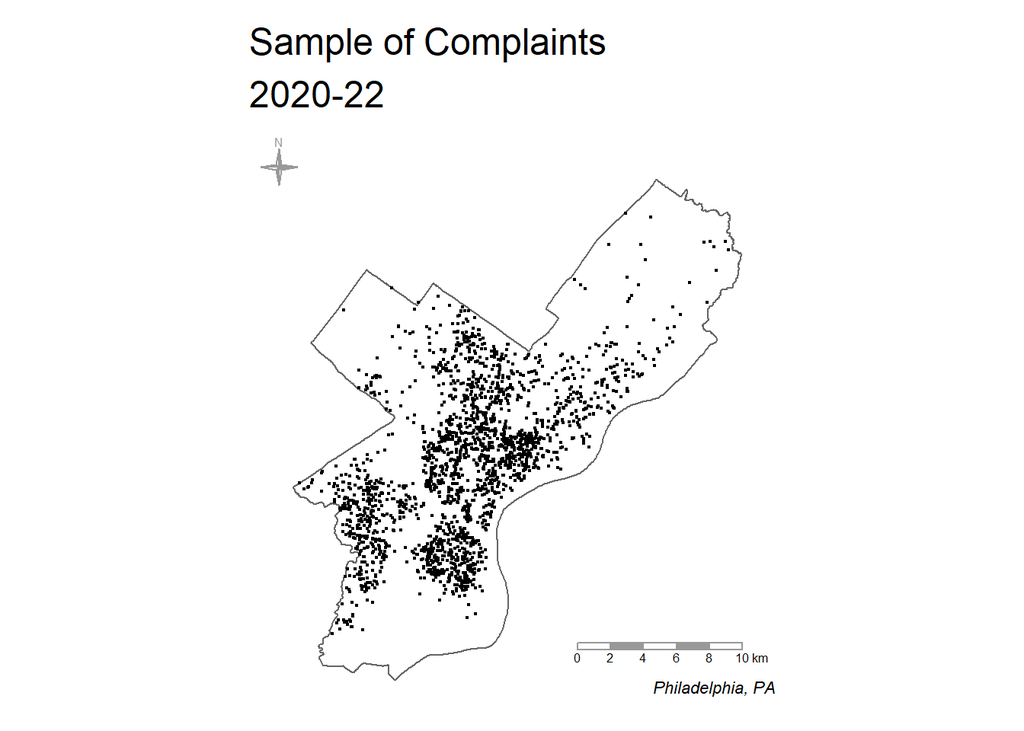

A map of 5% of dumping complaints, 2020-22

```r
tmap_mode('plot')

tm <- tm_shape(phl) +
  tm_borders() +
tm_shape(complaints_sample) +
  tm_dots(clustering = TRUE)

tmap_theme(tm, "Sample of Complaints\n2020-22")
```

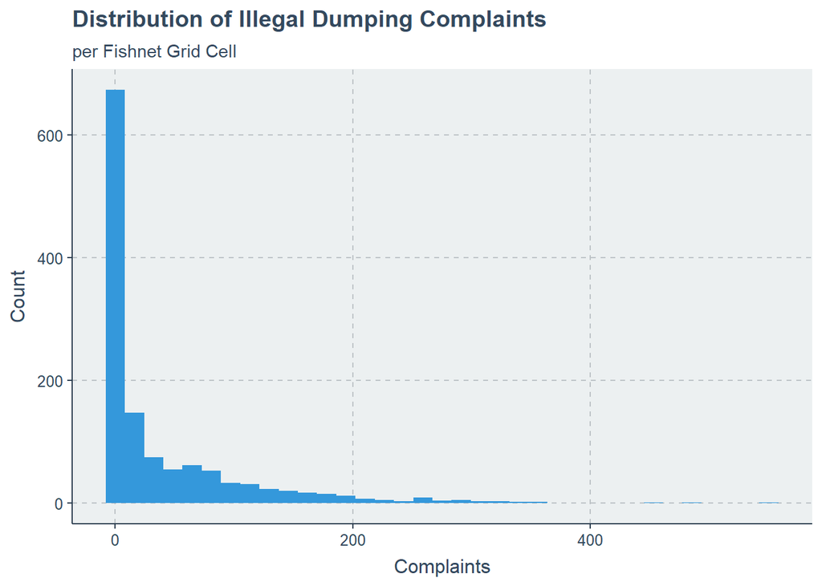

The distribution of illegal dumping across Philadelphia hexagon bins, 2020-22

```r
n_bins <- as.integer(sqrt(nrow(phl_grid)))

ggplot(full_net) +
  geom_histogram(aes(x = count_complaints), bins = n_bins) +
  labs(title = "Distribution of Illegal Dumping Complaints",
       subtitle = "per Fishnet Grid Cell",
       x = "Complaints",
       y = "Count")
```

## 3 Methods

### 3.1 Data Sources & Cleaning

A note on data: data are drawn from 2020 to 2022, the peak years of the COVID-19 pandemic. As a result, they are likely anomalous in many ways, such as the fact that the Kenney administration cut the sanitation department’s budget.

#### 3.1.1 The Fishnet Grid

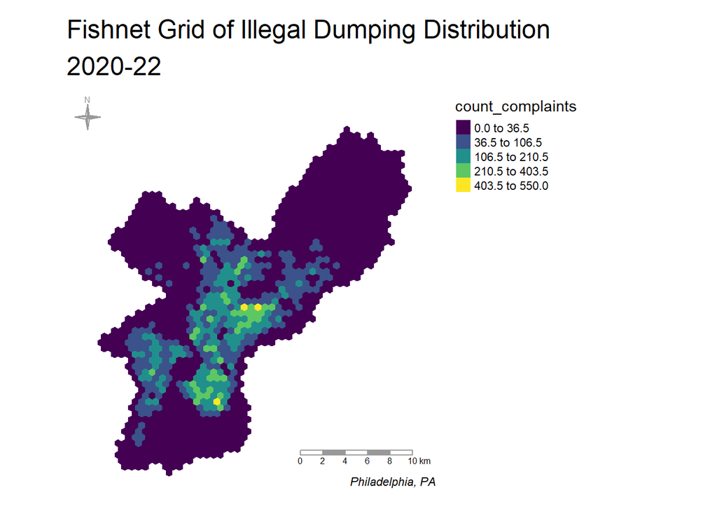

The distribution of illegal dumping across Philadelphia, 2020-22

```r
tmap_mode('plot')

tm <- tm_shape(dumping_net) +
  tm_polygons(col = "count_complaints", border.alpha = 0, style = "fisher", palette = "viridis")

tmap_theme(tm, "Fishnet Grid of Illegal Dumping Distribution\n2020-22")
```

Using local moran’s I calculations, we can identify hotspots of illegal dumping in Philadelphia.

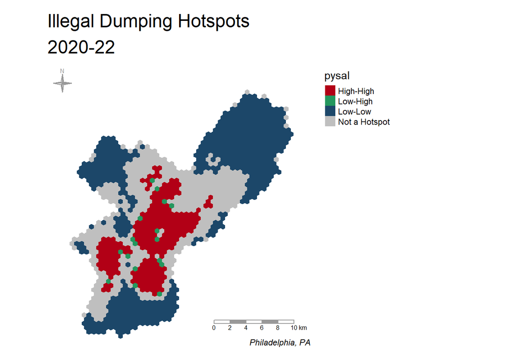

```r
dumping_net <- dumping_net %>%
                  mutate(nb = st_contiguity(x),
                         wt = st_weights(nb),
                         dumping_lag = st_lag(count_complaints, nb, wt))

lisa <- dumping_net %>%
  mutate(moran = local_moran(count_complaints, nb, wt)) %>%
  tidyr::unnest(moran) %>%
  mutate(pysal = ifelse(p_folded_sim <= 0.1, as.character(pysal), NA))

palette <- c("High-High" = "#B20016",
             "Low-Low" = "#1C4769",
             "Low-High" = "#24975E",
             "High-Low" = "#EACA97")

tm <- tm_shape(lisa) +
  tm_polygons(col = "pysal", border.alpha = 0, style = "cat", palette = palette, textNA = "Not a Hotspot")

tmap_theme(tm, "Illegal Dumping Hotspots\n2020-22")
```

#### 3.1.2 Correlations

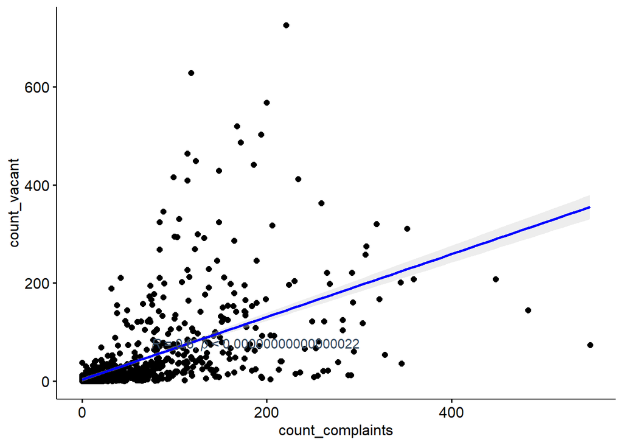

```r
ggscatter(full_net, x = "count_complaints", y = "count_vacant",
   add = "reg.line",  # Add regressin line
   add.params = list(color = "blue", fill = "lightgray"), # Customize reg. line
   conf.int = TRUE # Add confidence interval
   ) + stat_cor(method = "pearson", label.x = 75, label.y = 75)
```

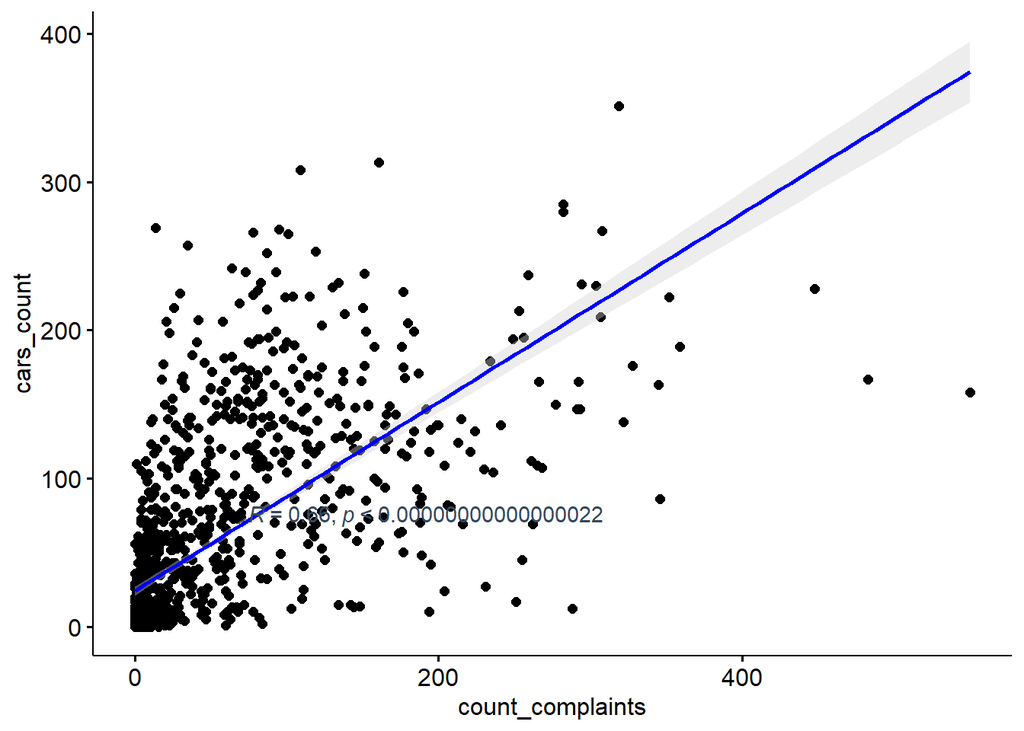

```r
ggscatter(full_net, x = "count_complaints", y = "cars_count",
   add = "reg.line",  # Add regressin line
   add.params = list(color = "blue", fill = "lightgray"), # Customize reg. line
   conf.int = TRUE # Add confidence interval
   ) + stat_cor(method = "pearson", label.x = 75, label.y = 75)
```

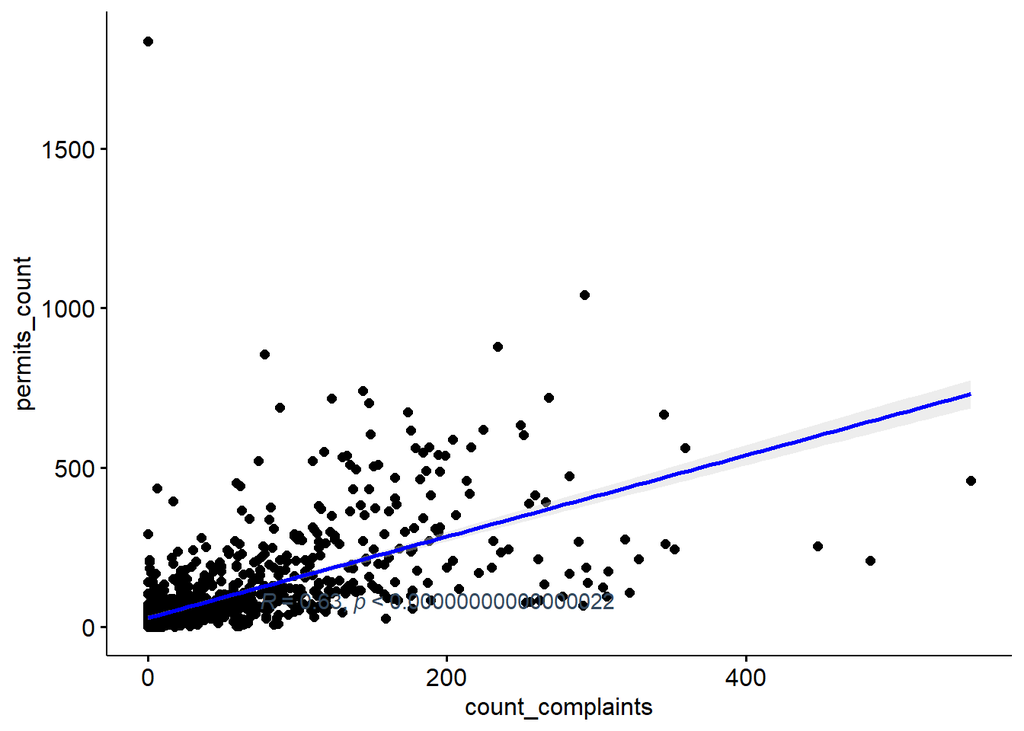

```r
ggscatter(full_net, x = "count_complaints", y = "permits_count",
   add = "reg.line",  # Add regressin line
   add.params = list(color = "blue", fill = "lightgray"), # Customize reg. line
   conf.int = TRUE # Add confidence interval
   ) + stat_cor(method = "pearson", label.x = 75, label.y = 75)
```

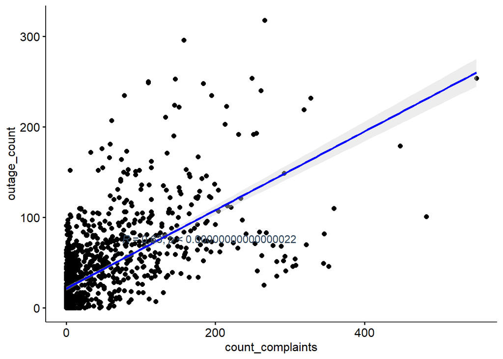

```r
ggscatter(full_net, x = "count_complaints", y = "outage_count",
   add = "reg.line",  # Add regressin line
   add.params = list(color = "blue", fill = "lightgray"), # Customize reg. line
   conf.int = TRUE # Add confidence interval
   ) + stat_cor(method = "pearson", label.x = 75, label.y = 75)
```

### 3.2 Model

Found that a regression tree had a lower MAE than a GLM, but oh, well.

### 3.3 Poisson Regression

## 4 Results

```r
reg_vars <- c("count_vacant",
              "cars_count",
              "outage_count",
              "permits_count",
              "count_complaints",
              "mapname")

reg_data <- full_net %>%
              dplyr::select(all_of(reg_vars)) %>%
              st_point_on_surface()
```

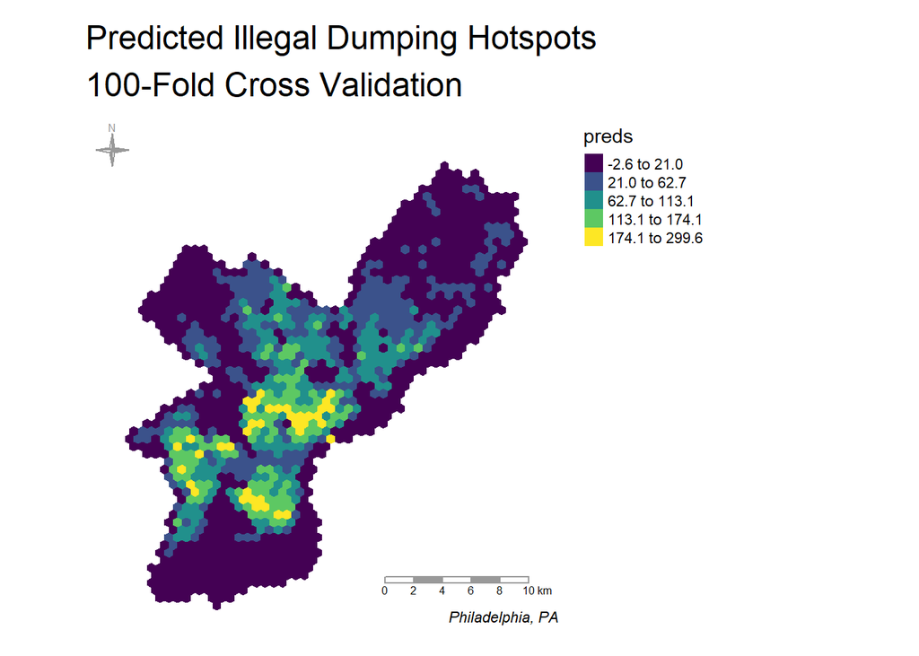

```r
fitControl <- trainControl(method = "cv",
                           number = 100)

reg_cv <- train(count_complaints ~ .,
                data = reg_data %>% select(-mapname) %>% st_drop_geometry(),
                 method = "glm",
                 trControl = fitControl)

reg_cv_sum <- data.frame(preds = reg_cv$finalModel$fitted.values)
reg_cv_sum$truth <- reg_cv$trainingData$`.outcome`
reg_cv_sum <- reg_cv_sum %>%
                  mutate(abs_error = abs(preds - truth))

to_map <- cbind(full_net, reg_cv_sum)

tm <- tm_shape(to_map) +
  tm_polygons(col = "preds", border.alpha = 0, style = "fisher", palette = "viridis")

tmap_theme(tm, "Predicted Illegal Dumping Hotspots\n100-Fold Cross Validation")
```

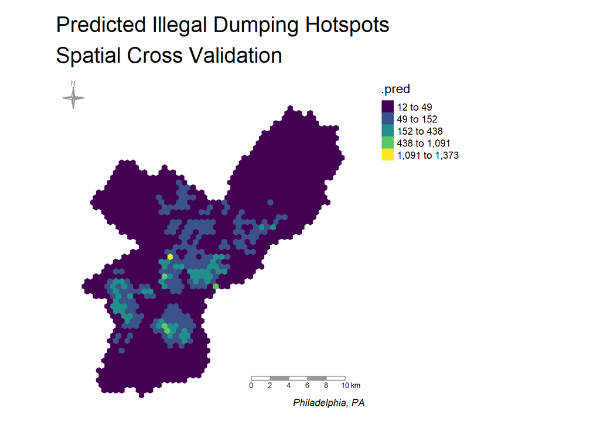

```r
cluster_folds <- spatial_leave_location_out_cv(st_drop_geometry(reg_data), mapname)
model_spec <- poisson_reg(mode = "regression") %>% set_engine("glm")
x <- recipes::recipe(count_complaints ~ count_vacant + cars_count + outage_count + permits_count, data = st_drop_geometry(reg_data))

results <- fit_resamples(model_spec, x, resamples = cluster_folds, metrics = metric_set(mae), control = control_grid(save_pred = TRUE))
predictions <- collect_predictions(results)
metrics <- collect_metrics(results, summarize = FALSE)
overall_metrics <- collect_metrics(results)

preds_net <- left_join(phl_grid, predictions, by = c("grid_id" = ".row")) %>%
                mutate(abs_error = abs(.pred - count_complaints)) %>%
                st_as_sf()

tm <- tm_shape(preds_net) +
  tm_polygons(col = ".pred", border.alpha = 0, style = "fisher", palette = "viridis")
tmap_theme(tm, "Predicted Illegal Dumping Hotspots\nSpatial Cross Validation")
```

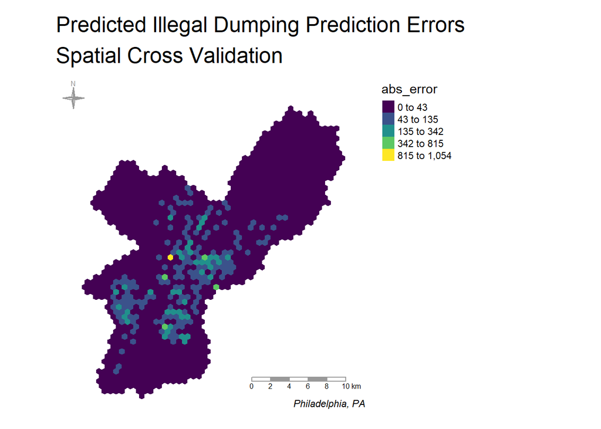

```r
tm <- tm_shape(preds_net) +
  tm_polygons(col = "abs_error", border.alpha = 0, style = "fisher", palette = "viridis")
tmap_theme(tm, "Predicted Illegal Dumping Prediction Errors\nSpatial Cross Validation")
```

Interestingly, we note that, while the regular k-fold cross validation produces normally-distributed errors, the spatial k-fold cross validation produces a bimodal (or possibly trimodal) distribution, suggesting that perhaps different neighborhoods are prone to much higher rates of prediction error.

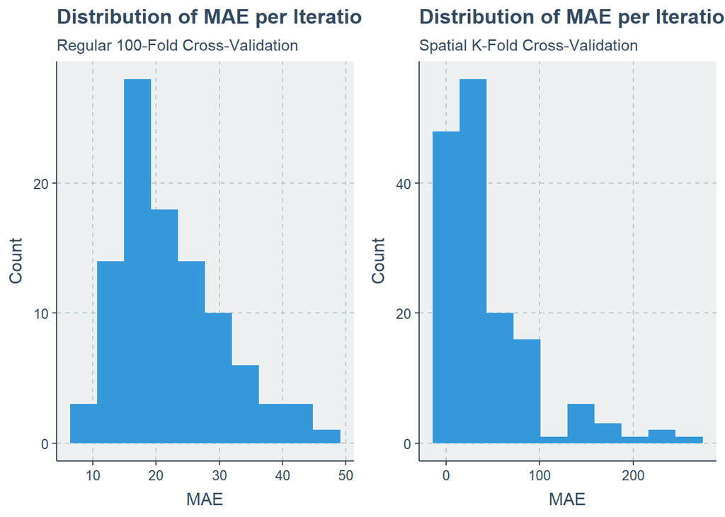

```r
reg_cv_mae_results <- data.frame(MAE = reg_cv$resample$MAE)

cv_mae_hist <- ggplot(reg_cv_mae_results, aes(x = MAE)) +
  geom_histogram(bins = 10) +
  labs(title = "Distribution of MAE per Iteration",
       subtitle = "Regular 100-Fold Cross-Validation",
       x = "MAE",
       y = "Count")

spcv_mae_hist <- ggplot(metrics, aes(x = .estimate)) +
  geom_histogram(bins = 10) +
  labs(title = "Distribution of MAE per Iteration",
       subtitle = "Spatial K-Fold Cross-Validation",
       x = "MAE",
       y = "Count")

ggarrange(cv_mae_hist, spcv_mae_hist)
```

We note taht the MAE with spatial cross-validation is much higher than the MAE for regular 100-fold cross-validation (twice as high, in fact).

```r
mae_df <- data.frame(
  model = c("100-Fold CV", "Spatial CV"),
  mae = c(reg_cv$results$MAE, overall_metrics$mean)
)

mae_df %>%
  mutate(mae = round(mae, 2)) %>%
  kbl(caption = "MAE by Validation Type") %>%
  kable_minimal(full_width = F)
```

MAE by Validation Type

| model | mae |
| --- | --- |
| 100-Fold CV | 22.34 |
| Spatial CV | 43.95 |

## 5 Discussion

### 5.1 Accuracy

### 5.2 Generalizability

#### 5.2.1 Racial Context

Aggregate model errors based on the racial makeup of neighborhoods in Philadelphia indicates that, whether we consider regular cross-fold validation or spatial cross-fold validation, our model performs worse in minority neighborhoods than in white neighborhoods. This indicates that it does not generalize across racial contexts.

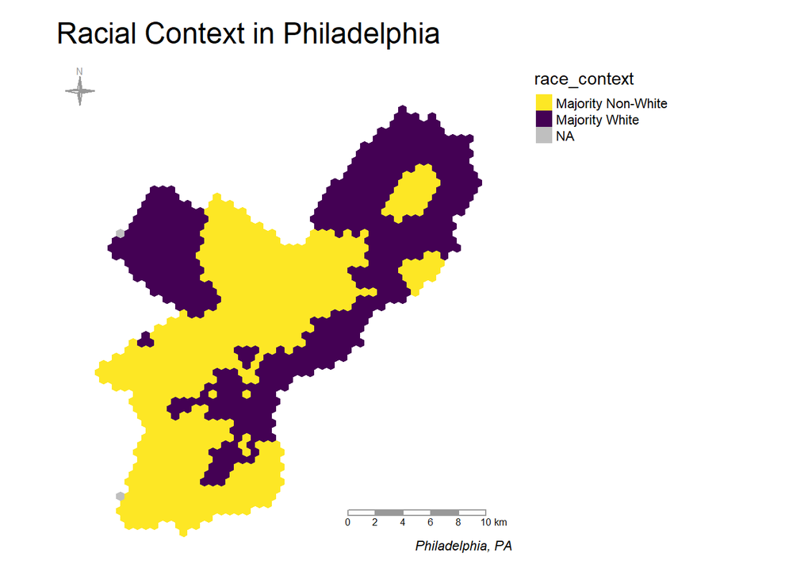

```r
phl_acs <- readRDS("Midterm/phl_acs.RData")
phl_acs <- phl_acs %>%
              mutate(race_context = ifelse(pctWhite > .5, "Majority White", "Majority Non-White"),
                     tract_id = 1:n())

acs_intersection <- st_intersection(phl_grid, phl_acs)
acs_intersection$intersection_area <- st_area(acs_intersection)
acs_max_intersection <- acs_intersection %>%
  group_by(grid_id) %>%
  filter(intersection_area == max(intersection_area)) %>%
  ungroup() %>%
  select(grid_id, tract_id) %>%
  st_drop_geometry()

grid_w_acs <- left_join(phl_grid, acs_max_intersection, by = c("grid_id" = "grid_id")) %>%
                        st_drop_geometry()


cv_race_context_df <- left_join(to_map, grid_w_acs)
cv_race_context_df <- left_join(cv_race_context_df, st_drop_geometry(phl_acs))

spcv_race_context_df <- left_join(preds_net, grid_w_acs)
spcv_race_context_df <- left_join(spcv_race_context_df, st_drop_geometry(phl_acs))

mae_x_race_cv <- cv_race_context_df %>%
  st_drop_geometry() %>%
  group_by(race_context) %>%
  summarize(cv_avg_error = mean(abs_error))

mae_x_race_spcv <- spcv_race_context_df %>%
  st_drop_geometry() %>%
  group_by(race_context) %>%
  summarize(spcv_avg_error = mean(abs_error))

mae_x_race <- left_join(mae_x_race_cv, mae_x_race_spcv)

tm <- tm_shape(cv_race_context_df) +
  tm_polygons(col = "race_context", border.alpha = 0, style = "cat", palette = "-viridis", textNA = "NA")
tmap_theme(tm, "Racial Context in Philadelphia")
```

```r
mae_x_race %>%
  kbl(caption = "MAE by Race Context and Model") %>%
  kable_minimal(full_width = F)
```

MAE by Race Context and Model

| race_context | cv_avg_error | spcv_avg_error |
| --- | --- | --- |
| Majority Non-White | 26.407890 | 34.74881 |
| Majority White | 16.984825 | 21.93670 |
| NA | 2.600035 | 12.08971 |

Here, we implement a kernel density estimate using an adaptive bandwidth.

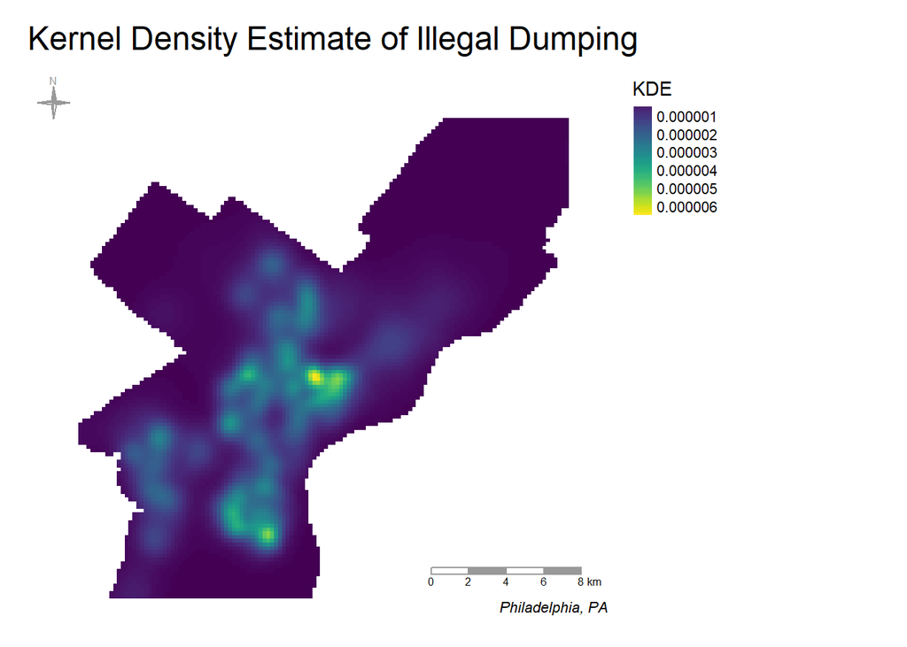

```r
source("R/st_kde.R")

dumping_kde <- st_kde(complaints_sample)
terra::crs(dumping_kde) <- crs
dumping_kde_phl <- terra::mask(dumping_kde, phl)

tm <- tm_shape(dumping_kde_phl) +
  tm_raster(palette = 'viridis', title = "KDE", style = "cont")
tmap_theme(tm, "Kernel Density Estimate of Illegal Dumping")
```

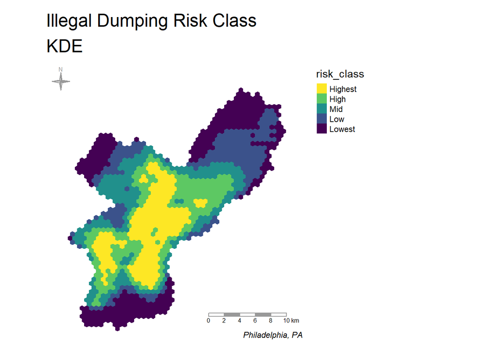

```r
kde_2_grid <- terra::extract(x = dumping_kde, phl_grid)

kde_2_grid_summary <- group_by(kde_2_grid, ID) |>
  summarize(across(lyr.1, list(min = min, mean = mean, max = max, sum = sum)))

kde_grid <- left_join(phl_grid, kde_2_grid_summary, by = c("grid_id" = "ID"))%>%
              mutate(scaled_risk = rescale(lyr.1_sum, c(0, 100)))

kde_risk_ints <- classIntervals(kde_grid$scaled_risk, style = "quantile", n = 5)

kde_grid <- kde_grid %>%
              mutate(risk_class = case_when(
                scaled_risk >= kde_risk_ints$brks[5] ~ "Highest",
                scaled_risk < kde_risk_ints$brks[5] &  scaled_risk >= kde_risk_ints$brks[4] ~ "High",
                scaled_risk < kde_risk_ints$brks[4] &  scaled_risk >= kde_risk_ints$brks[3] ~ "Mid",
                scaled_risk < kde_risk_ints$brks[3] &  scaled_risk >= kde_risk_ints$brks[2] ~ "Low",
                TRUE ~ "Lowest"
              ))

kde_grid$risk_class <- factor(kde_grid$risk_class, c("Highest", "High", "Mid", "Low", "Lowest"))

tm <- tm_shape(kde_grid) +
  tm_polygons(col = "risk_class", border.alpha = 0, style = "cont", palette = "-viridis")
tmap_theme(tm, "Illegal Dumping Risk Class\nKDE")
```

(Shouldn’t matter if we use the whole year bc the comparison is relative, not pred. vs actual)

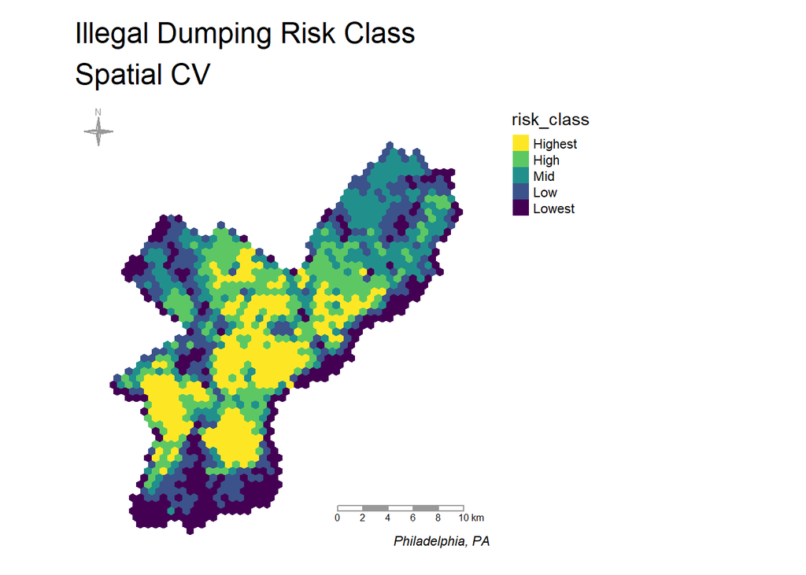

```r
preds_net <- preds_net %>%
              mutate(scaled_risk = rescale(.pred, c(0, 100)))

risk_ints <- classIntervals(preds_net$scaled_risk, style = "quantile", n = 5)

preds_net <- preds_net %>%
              mutate(risk_class = case_when(
                scaled_risk >= risk_ints$brks[5] ~ "Highest",
                scaled_risk < risk_ints$brks[5] &  scaled_risk >= risk_ints$brks[4] ~ "High",
                scaled_risk < risk_ints$brks[4] &  scaled_risk >= risk_ints$brks[3] ~ "Mid",
                scaled_risk < risk_ints$brks[3] &  scaled_risk >= risk_ints$brks[2] ~ "Low",
                TRUE ~ "Lowest"
              ))

preds_net$risk_class <- factor(preds_net$risk_class, c("Highest", "High", "Mid", "Low", "Lowest"))

tm <- tm_shape(preds_net) +
  tm_polygons(col = "risk_class", border.alpha = 0, style = "cat", palette = "-viridis")
tmap_theme(tm, "Illegal Dumping Risk Class\nSpatial CV")
```

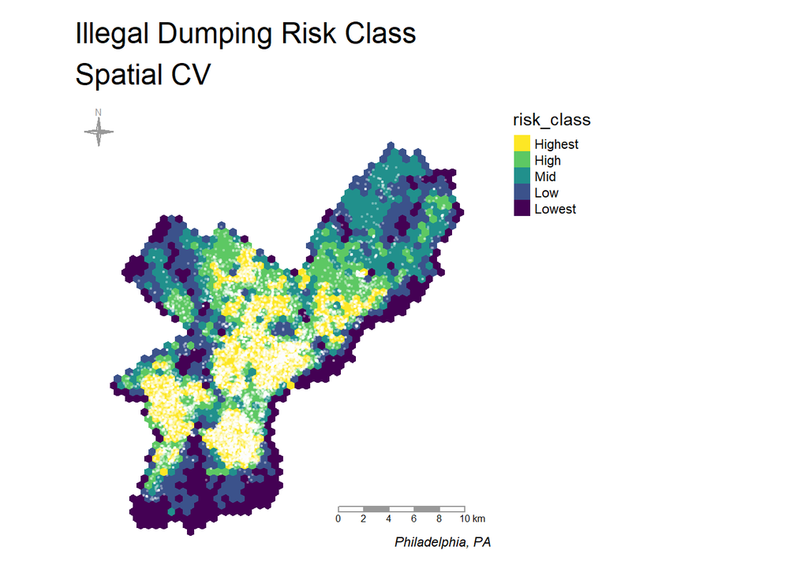

```r
# recent_dumping_query <- sprintf("
#                   SELECT *
#                   FROM public_cases_fc
#                   WHERE requested_datetime >= '%s'
#                  ", one_year_ago)
#
# dumping_strings <- c("Illegal Dumping")
# recent_complaints <- get_complaints(recent_dumping_query, base_url, dumping_strings)
#
# recent_complaints <- recent_complaints |>
#   mutate(
#     closed_datetime = ifelse(closed_datetime == "", NA, closed_datetime),
#     response_time_days = case_when(
#       is.na(closed_datetime) ~ as.numeric(difftime(Sys.Date(), requested_datetime, units = "days")),
#       TRUE ~ as.numeric(difftime(
#         closed_datetime, requested_datetime, units = "days"
#       ))
#     ),
#     count_complaints = 1
#   )

recent_complaints_path <- "hw3_data/recent_complaints.geojson"
# saveRDS(recent_complaints, recent_complaints_path)
recent_complaints <- readRDS(recent_complaints_path)

recent_complaints_net <- st_join(phl_grid, recent_complaints) %>%
                  group_by(grid_id) %>%
                  summarize(count_recent_complaints = sum(count_complaints),
                            count_recent_complaints = ifelse(is.na(count_recent_complaints), 0, count_recent_complaints))

tm <- tm_shape(preds_net) +
  tm_polygons(col = "risk_class", border.alpha = 0, style = "cat", palette = "-viridis") +
      tm_shape(slice_sample(recent_complaints, prop = .5)) +
          tm_dots(col = "white", alpha = 0.2)
tmap_theme(tm, "Illegal Dumping Risk Class\nSpatial CV")
```

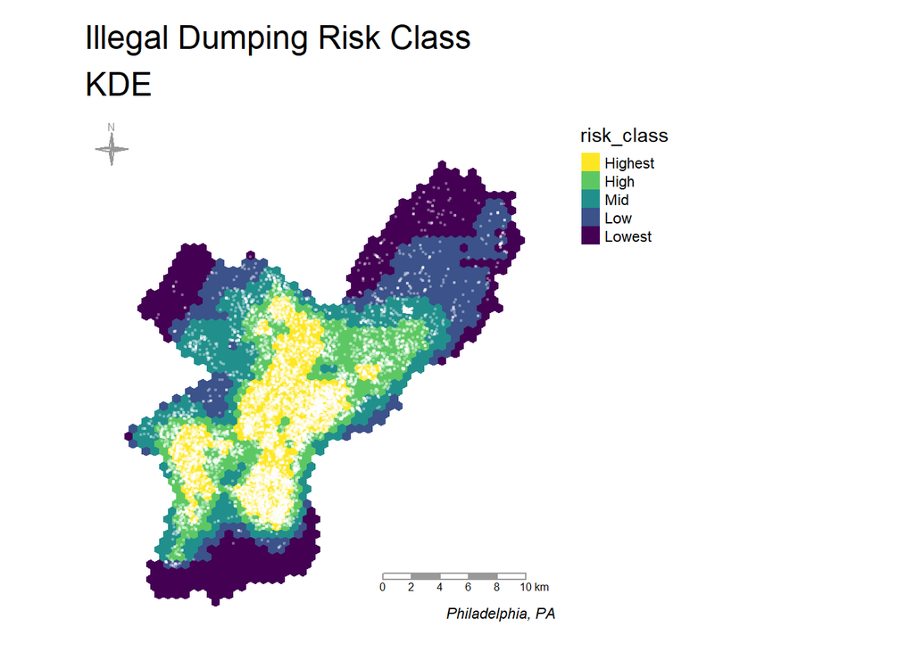

```r
tm <- tm_shape(kde_grid) +
  tm_polygons(col = "risk_class", border.alpha = 0, style = "cont", palette = "-viridis")+
      tm_shape(slice_sample(recent_complaints, prop = .5)) +
          tm_dots(col = "white", alpha = 0.2)
tmap_theme(tm, "Illegal Dumping Risk Class\nKDE")
```

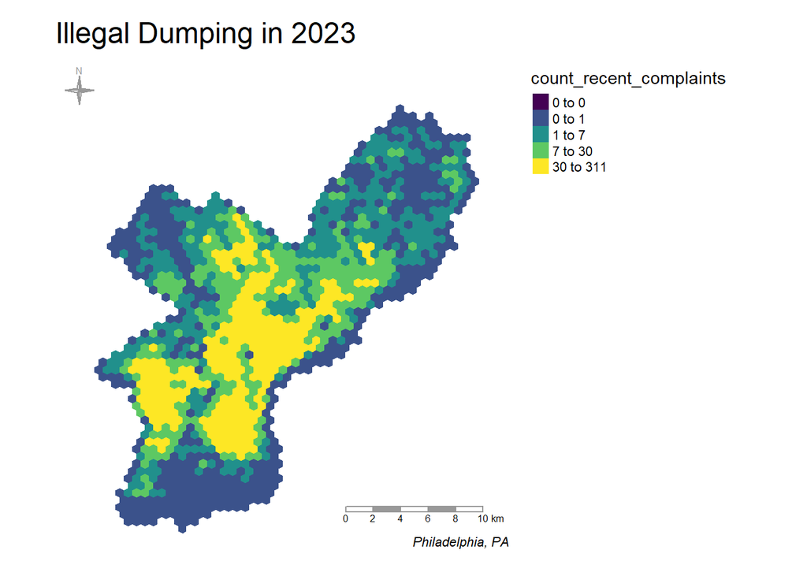

```r
tm <- tm_shape(recent_complaints_net) +
  tm_polygons(col = "count_recent_complaints", border.alpha = 0, style = "quantile", palette = "viridis")
tmap_theme(tm, "Illegal Dumping in 2023")
```

But I found that this was highly dependent on how I define the class breaks for the model. For instance, when I use quantile breaks, SPCV outperforms KDE. But when I use Jenks breaks, the KDe outperforms the SPCV.

Could rewrite this section with rbind and stack the dataframes instead…

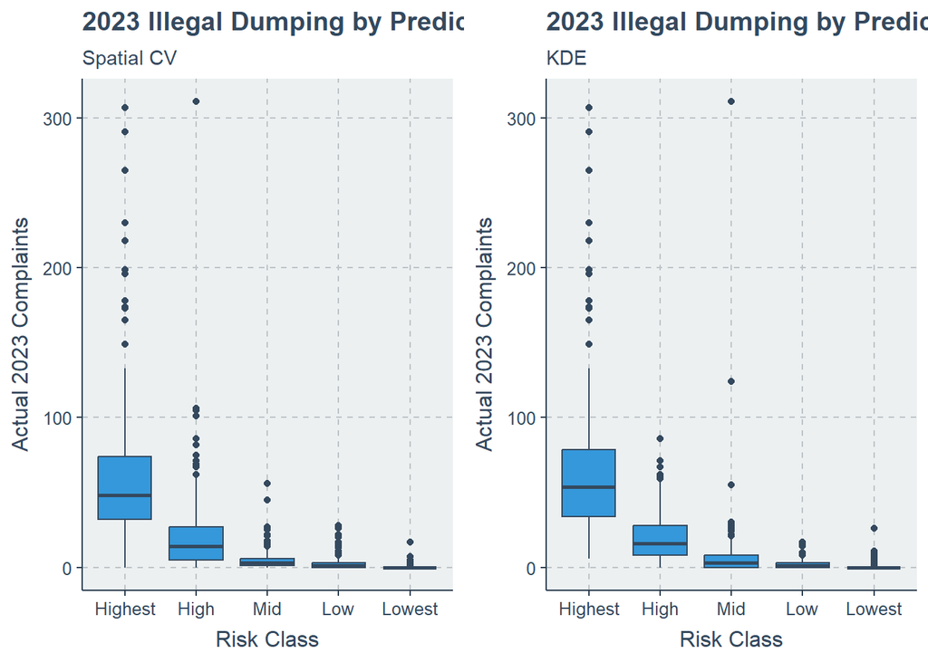

```r
preds_net <- left_join(preds_net, st_drop_geometry(recent_complaints_net))

spcv_preds_boxplot <- ggplot(preds_net) +
  geom_boxplot(aes(x = risk_class, y = count_recent_complaints)) +
  labs(title = "2023 Illegal Dumping by Predicted Risk",
       subtitle = "Spatial CV",
       x = "Risk Class",
       y = "Actual 2023 Complaints")


kde_grid <- left_join(kde_grid, st_drop_geometry(recent_complaints_net))

kde_preds_boxplot <- ggplot(kde_grid) +
  geom_boxplot(aes(x = risk_class, y = count_recent_complaints)) +
  labs(title = "2023 Illegal Dumping by Predicted Risk",
       subtitle = "KDE",
       x = "Risk Class",
       y = "Actual 2023 Complaints")

ggarrange(spcv_preds_boxplot, kde_preds_boxplot, ncol = 2)
```

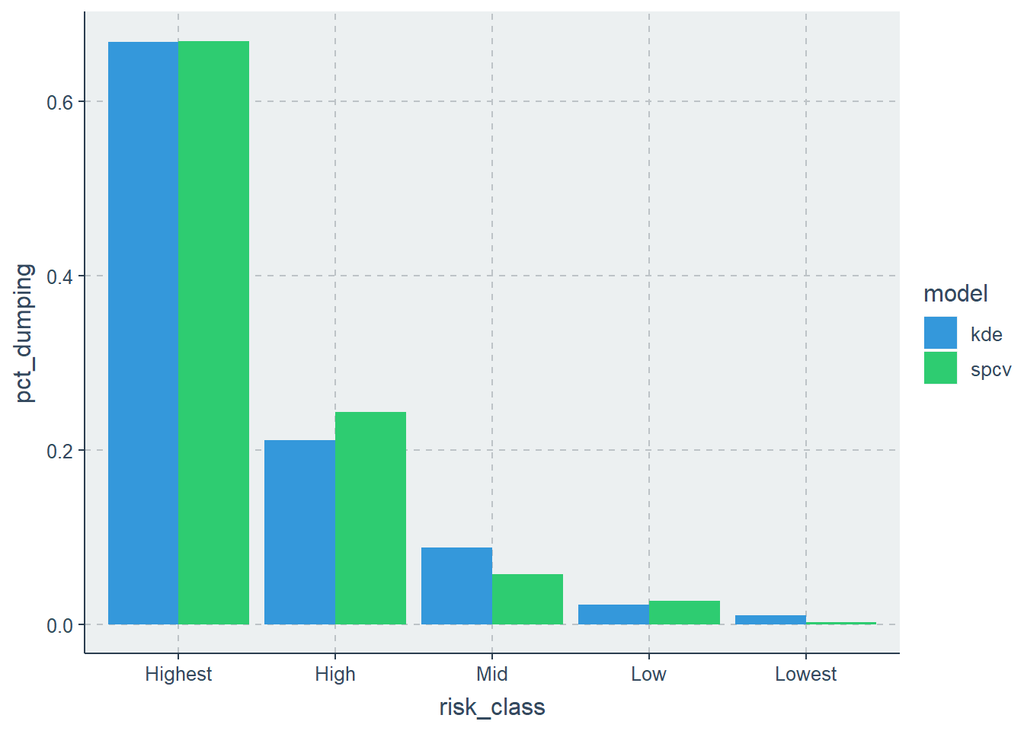

```r
preds_net_predicted <- preds_net %>%
  st_drop_geometry() %>%
  group_by(risk_class) %>%
  summarize(spcv_tot_dumping = sum(count_recent_complaints)) %>%
  mutate(spcv_pct_dumping = spcv_tot_dumping / sum(spcv_tot_dumping))

kde_grid_predicted <-kde_grid %>%
  st_drop_geometry() %>%
  group_by(risk_class) %>%
  summarize(kde_tot_dumping = sum(count_recent_complaints)) %>%
  mutate(kde_pct_dumping = kde_tot_dumping / sum(kde_tot_dumping))

predicted_compared <- left_join(preds_net_predicted, kde_grid_predicted)

predicted_compared_long <- predicted_compared %>%
  select(risk_class, contains("pct_dumping")) %>%
  pivot_longer(cols = -risk_class,
               names_to = "model_pct",
               values_to = "pct_dumping") %>%
  mutate(model = gsub("_pct_dumping", "", model_pct)) %>%
  select(-model_pct)

ggplot(predicted_compared_long) +
  geom_col(aes(x = risk_class, y = pct_dumping, fill = model), position = "dodge")
```

## 6 Conclusion

- Model is not especially accurate
- Does not generalize across racial contexts, and likely not across other contexts, either
- SPCV indicates significant error due to autocorrelation
- SPCV also isn’t really much of an improvement over KDE, if at all
- Also seems to be highly sensitive to input parameters such as grid cell size or evaluation parameters like class breaks
- Overall, too much of the model seems sensitive to too many things, and it does not present a clear improvement over the KDE approach.